# Evaluating Innovation System Performance – From simple to complex indicators

Daniel S. Hain (dsh@business.aau.dk)

26 March, 2020

## 0.1 Introduction

### 0.1.1 This Lecture

- We briefly discuss how innovation system characteristics can be measured.
- However, focus lies on how we can easily optain data to do so, and what needs to be done with it.
- While manipulating and visualizing, you will develop an intuition for these indicators.
- You will optain skills enabling you to work with multiple sources of indicators, bring them in the shape you need, and analyze/visualize this data.

### 0.1.2 Some intial questions

1. What is Innovation System Performance?
2. How could we measure it?
3. Who should care, and why?

### 0.1.3 Handpicked indicators

- Organizations such as the OECD or WorldBank provide a lot of statistics which could be used to measure innovation system characteristics
- These represent a mixed-bag of economic output, patent statistics, and survey data.
- Many can be used to measure characteristics of Innovation Systemd
- However, what do they measure? IS characteristics? Input? Output?
- Ecample: The [OECD Science, Technology and Innovation Outlook](https://www.oecd-ilibrary.org/science-and-technology/oecd-science-technology-and-innovation-outlook_25186167)

### 0.1.4 Composite indicators

- Quite a set of institutions provide also provide methodologies to produce **composite** indictors, which aggregate stand-alone indicators on different levels.
- Again, input vs. output vs. throughput vs. efficiency indicators.
- And, what do we capture when we aggregate to high?
- An widely used source is the Global Innovation Index

## 0.2 The OECD Science, Technology, and Innovation (STI) Outlook

### 0.2.1 Introduction

- [OECD Science, Technology, and Innovation (STI) O1utlook](https://read.oecd-ilibrary.org/science-and-technology/oecd-science-technology-and-innovation-outlook-2018_sti_in_outlook-2018-en#page1) (`STIO_2016`)
- Biennial review of key trends in science, technology and innovation (STI) policy in OECD countries and a number of major partner economies.
- We use the `OECD` library `R` to coveniently access data.
- unfortunatelly only available in the 2016 (newest is 2018) version of the dataset.
- For adittional information on the variables and their construction, check the metadata (`OECD::browse_metadata("STIO_2016")`)

### 0.2.2 Exploring the database

We can easily browse through all available datasets provided by the OECD

```r
dataset_list <- OECD::get_datasets()
search_string <- "science|technology|innovation"
OECD::search_dataset(search_string, data = dataset_list)
```

| id | title |
| --- | --- |
| PATS_IPC | Patents by technology |
| MSTI_PUB | Main Science and Technology Indicators |
| PAT_COL_RATES | Patents - International collaboration in technology development (rates) |
| CIIE10 | Part 1 - Comparing innovation in education with other sectors |
| GERD_SCIENCE | Gross domestic expenditure on R-D by sector of performance and field of science |
| PERS_SCIENCE | R-D personnel by sector of employment and field of science |
| ONRD_FUNDS | Other national R-D expenditure by field of science and by source of funds |
| ONRD_COST | Other national R&D expenditure by field of science and by type of cost |
| PAT_COL | Patents - International collaboration in technology development (bilateral) |
| PART2 | Part 2 - Innovation as change in classrooms and schools |

[output cut: 12 more lines]

With the `get_data_structure()` function of the package, we can inspect what we are going to find.

```r
dstruc <- OECD::get_data_structure("STIO_2016")
str(dstruc, max.level = 1)
```

```
## List of 6
##  $ VAR_DESC   :'data.frame': 6 obs. of  2 variables:
##  $ COUNTRY    :'data.frame': 52 obs. of  2 variables:
##  $ INDICATOR  :'data.frame': 715 obs. of  2 variables:
##  $ YEAR       :'data.frame': 17 obs. of  2 variables:
##  $ OBS_STATUS :'data.frame': 15 obs. of  2 variables:
##  $ TIME_FORMAT:'data.frame': 5 obs. of  2 variables:
```

We see the output will be a `list` format. The `INDICATOR` dataframe here contains the description of the indicators. Letys take a look:

```r
dstruc$INDICATOR
```

| id | label |
| --- | --- |
| RD | Research and Development (R&D) expenditure (select) |
| GERD | R&D, all performers (select) |
| G | GERD (Gross domestic expenditure on R&D) (select) |
| G_NC | GERD, million NC |
| G_PPP | GERD, million USD PPPs |
| G_PPPK | GERD, million constant USD PPPs |
| G_XGDP | GERD, % of GDP |
| G_XO | GERD, OECD share, % |
| G_XW | GERD, world share estimate, % |
| G_GRO | GERD, compound annual growth rate at constant prices, % |

[output cut: 705 more lines]

### 0.2.3 Select Indicators & download

We will focus on a selection of indicators (not encessarily the best, just a quick selection of potentially relevant ones).

```r
vars <- c("GDP_PPPK", "GDP_HAB_PPPK", "GDP_GRO", "POP_NB", "G_XGDP", "BE_XGDP", "GV_XGDP", "RDPERS_EMP", "PTRIAD_GDP", "UNI500_HAB")
```

I here provide you a selection of different types iof indicators, related to:

- General population, size of the economy, and growth (`POP_NB, GDP_PPPK, GDP_GRO`)
- Inputs: STI investments (`G_XGDP, BE_XGDP, GV_XGDP`)
- Throughputs: R&D personal and top universities (`RDPERS_EMP, UNI500_HAB`)
- Output: Patents (`PTRIAD_GDP`)

We now in real-time download the data with the `get_dataset` function.

```r
data_raw <- OECD::get_dataset(dataset = "STIO_2016", filter = list (dstruc$COUNTRY$id, vars))
# saveRDS(data_raw, "media/data_raw.RDS") # in case we want to save it and not always download it again
```

Lets see what we got

```r
data_raw %>% head()
```

| COUNTRY | INDICATOR | TIME_FORMAT | obsTime | obsValue | OBS_STATUS |
| --- | --- | --- | --- | --- | --- |
| AUS | G_XGDP | P1Y | 2000 | 1.48 | NA |
| AUS | G_XGDP | P1Y | 2002 | 1.65 | NA |
| AUS | G_XGDP | P1Y | 2004 | 1.73 | NA |
| AUS | G_XGDP | P1Y | 2006 | 2.00 | NA |
| AUS | G_XGDP | P1Y | 2008 | 2.25 | NA |
| AUS | G_XGDP | P1Y | 2010 | 2.19 | NA |

## 0.3 Data Prepereation

Before we dive into the analysis, we need to do a bit of data cleaning and munginging. Withn this type of macro data we usually have some or all of the following problems (for OECD but also WorldBank, EuroStats etc.):

1. Confusing or unintuitive variable names
2. Variable type and formatting issues
3. Country name issues
4. Data Structure (long vs. wide)
5. Missing data

### 0.3.1 Fomating & variable names

Here a very brief first renaming and formating. In detail, we do:

- Deselect variables we do not need
- Dename some for convenience
- Change the format of `year` from `character` to `numeric`
- Sort the data

```r
data <- data_raw %>%
  select(-TIME_FORMAT, -OBS_STATUS) %>%
  rename(ctry.iso3 = COUNTRY,
         indicator = INDICATOR,
         year = obsTime,
         value = obsValue) %>%
  mutate(year = year %>% as.numeric()) %>%
  arrange(ctry.iso3, indicator, year)
```

### 0.3.2 Country Names

- **Note:** The country here is coded in `iso3` format.
- I will here use the functionality of the `countrycode` packag (might need install)
- Note the `%<>%` pipe from the `magrittr` package, which assigns and executes jointly (`x <- x %>% ... == x %<>%...`)

```r
data %<>%
  mutate(ctry.name = ctry.iso3 %>% countrycode::countrycode("iso3c", "country.name"))
```

We will later also do summaries ofer 5 year time frames. Therefore I here already define a variable `period`.

```r
data %<>%
  group_by(ctry.iso3, indicator) %>%
  mutate(value = if_else(is.na(value), lag(value), value) ) %>%
  ungroup() %>%
  mutate(period = case_when(year <= 2005 ~ 1,
                            year > 2005 & year <= 2010 ~ 2,
                            year > 2010 ~ 3)) %>%
  select(ctry.iso3, ctry.name, year, period, everything())
```

Lets see what the final data looks like

```r
data %>% head()
```

| ctry.iso3 | ctry.name | year | period | indicator | value |
| --- | --- | --- | --- | --- | --- |
| ARG | Argentina | 2000 | 1 | BE_XGDP | 0.09 |
| ARG | Argentina | 2001 | 1 | BE_XGDP | 0.08 |
| ARG | Argentina | 2002 | 1 | BE_XGDP | 0.08 |
| ARG | Argentina | 2003 | 1 | BE_XGDP | 0.10 |
| ARG | Argentina | 2004 | 1 | BE_XGDP | 0.12 |
| ARG | Argentina | 2005 | 1 | BE_XGDP | 0.12 |

### 0.3.3 Data structure (pivoting)

- We also see that the data has a `long` (also called `tidy`) format, meaning the variables to be found in the rows rather than the columns, where the variable name is to be found in the `indicator` column.
- This is a typical data structure you will often obtain from statistical offices, the OECD, the Worldbank and so forth.
- This is sometimes really convenient for plotting and providing summaries of many variables.
- For other tasks, however, we require a `wide` format, where the variables are to be found on the columns. We will use the `pivot_wider()` funcction to do so.

```r
data_wide <- data %>%
  pivot_wider(names_from = indicator, values_from = value)
```

Lets take a look what that looks like now

```r
data_wide %>% head()
```

| ctry.iso3 | ctry.name | year | period | BE_XGDP | G_XGDP | GDP_GRO | GDP_HAB_PPPK | GDP_PPPK | GV_XGDP | PTRIAD_GDP | RDPERS_EMP | POP_NB | UNI500_HAB |
| --- | --- | --- | --- | --- | --- | --- | --- | --- | --- | --- | --- | --- | --- |
| ARG | Argentina | 2000 | 1 | 0.09 | 0.37 | NA | NA | NA | 0.14 | 0.02 | 2.86 | NA | NA |
| ARG | Argentina | 2001 | 1 | 0.08 | 0.35 | NA | NA | NA | 0.14 | 0.02 | 2.92 | NA | NA |
| ARG | Argentina | 2002 | 1 | 0.08 | 0.33 | NA | NA | NA | 0.12 | 0.02 | 2.85 | NA | NA |
| ARG | Argentina | 2003 | 1 | 0.10 | 0.34 | NA | NA | NA | 0.14 | 0.02 | 2.89 | NA | NA |
| ARG | Argentina | 2004 | 1 | 0.12 | 0.37 | NA | 14270.27 | 546676.9 | 0.14 | 0.02 | 2.77 | NA | NA |
| ARG | Argentina | 2005 | 1 | 0.12 | 0.38 | 8.89 | 15402.46 | 595272.8 | 0.15 | 0.03 | 2.86 | NA | NA |

## 0.4 First visual inspection

- Now it is time for some first visualization. We will explore:
  - The correlation between different indicators
  - The conditional distribution between indicators
- We will soon do some own ones with the `ggplot2` package.
- Here for now use the `GGally` packages, which builds on `ggplot2` and offers some nice standard exploratory visualizations.

### 0.4.1 Correlation & Distribution structure

First, lets look at the correlation matrix.

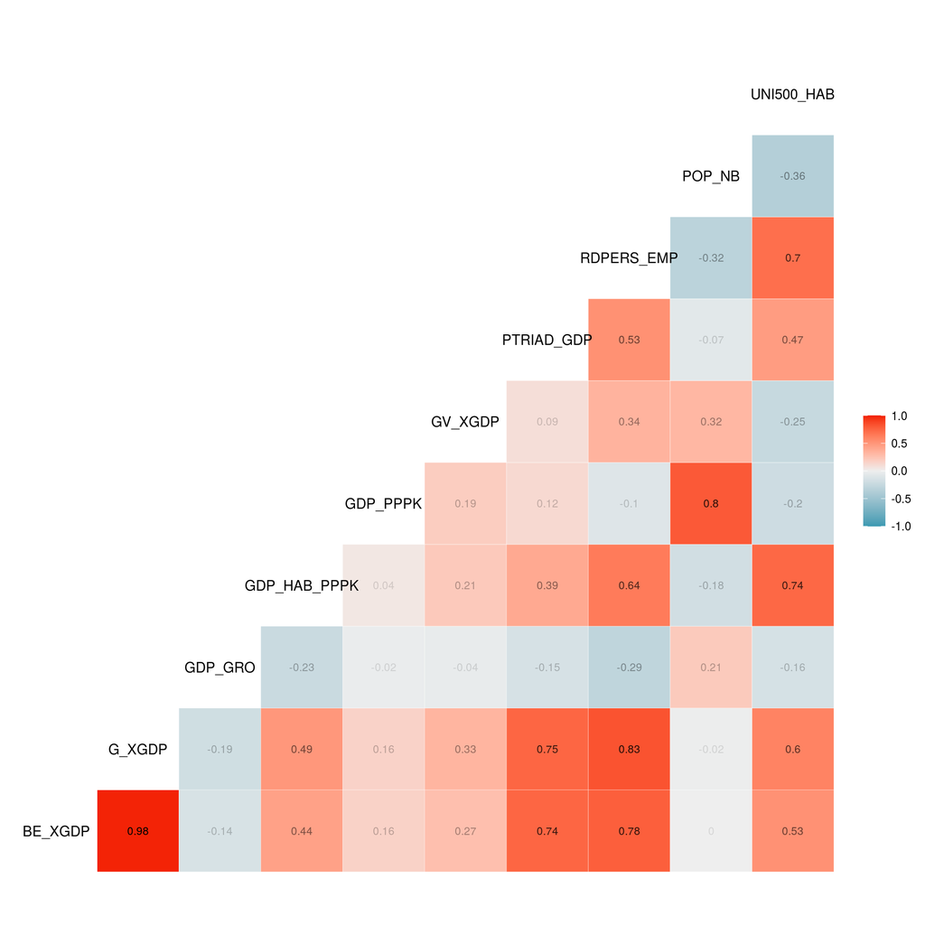

```r
data_wide %>%
  select(-ctry.iso3, -ctry.name, -year, -period) %>%
  ggcorr(label = TRUE, label_size = 3, label_round = 2, label_alpha = TRUE)
```

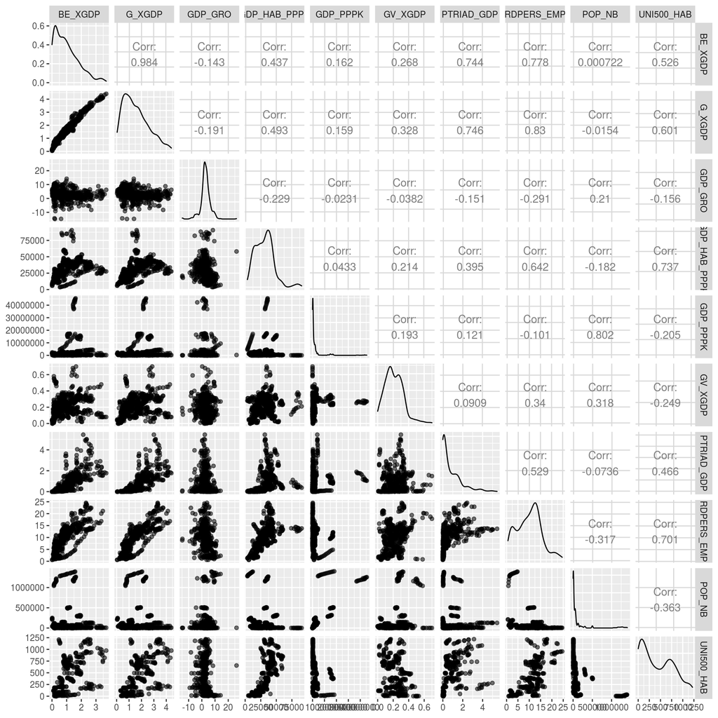

```r
data_wide %>%
  select(-ctry.iso3, -ctry.name, -year, -period) %>%
  ggpairs(aes(alpha = 0.3),
          ggtheme = theme_gray())
```

## 0.5 Static rankings

- After getting an overview on the general indicator behavior, lets see how the different countries do.
- The most simple thing is just to see a barplot stile ranking of countries.
- We start with getting an overall overview over the whole time.
- We use the `group_by()` and `summarize()` to aggregate the variables by their mean on country level:

```r
data_wide_agg <- data_wide %>%
  select(-year, -period) %>%
  filter( !(ctry.iso3 %in% c("OECD", "EU28"))) %>%
  group_by(ctry.iso3, ctry.name) %>%
  summarize_all(mean, na.rm = TRUE) %>%
  ungroup()
```

Lets see what we got…

```r
data_wide_agg %>% head()
```

| ctry.iso3 | ctry.name | BE_XGDP | G_XGDP | GDP_GRO | GDP_HAB_PPPK | GDP_PPPK | GV_XGDP | PTRIAD_GDP | RDPERS_EMP | POP_NB | UNI500_HAB |
| --- | --- | --- | --- | --- | --- | --- | --- | --- | --- | --- | --- |
| ARG | Argentina | 0.118000 | 0.4486667 | 3.790000 | 17942.89 | 723477.3 | 0.1880000 | 0.01785714 | 3.381333 | NaN | NaN |
| AUS | Australia | 1.083846 | 1.9412500 | 2.926250 | 41130.45 | 884465.0 | 0.2722222 | 0.55214286 | 12.043333 | 21404.059 | 784.01500 |
| AUT | Austria | 1.792500 | 2.5106250 | 1.495000 | 41015.83 | 340485.8 | 0.1300000 | 1.23785714 | 13.663333 | 8301.935 | 787.47750 |
| BEL | Belgium | 1.408000 | 2.0186667 | 1.549375 | 39237.48 | 420198.6 | 0.1586667 | 1.28928571 | 13.428667 | 10777.892 | 644.08750 |
| BRA | Brazil | NaN | 1.0871429 | 3.698182 | 12628.72 | 2356458.2 | NaN | 0.01769231 | 2.172727 | 188486.435 | 28.56833 |
| CAN | Canada | 1.036000 | 1.8793333 | 2.171250 | 39930.34 | 1327257.2 | 0.1860000 | 0.55000000 | 13.054286 | 33444.164 | 649.61250 |

### 0.5.1 GPD growth

- First, lets take a look at a classical economic indicator, GDP growth.
- Notice the `reorder` function, since otherwise countries would be ordered by name.

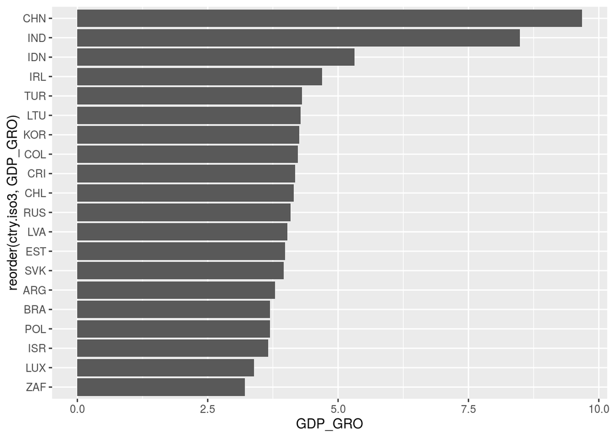

```r
data_wide_agg %>%
  arrange(desc(GDP_GRO)) %>%
  slice(1:20) %>%
  ggplot(aes(x = reorder(ctry.iso3, GDP_GRO), y = GDP_GRO)) +
  geom_bar(stat="identity") +
  coord_flip()
```

### 0.5.2 Gross domestic expenditure on R&D (GERD)

- Next, lets look at some input, such as GERD.

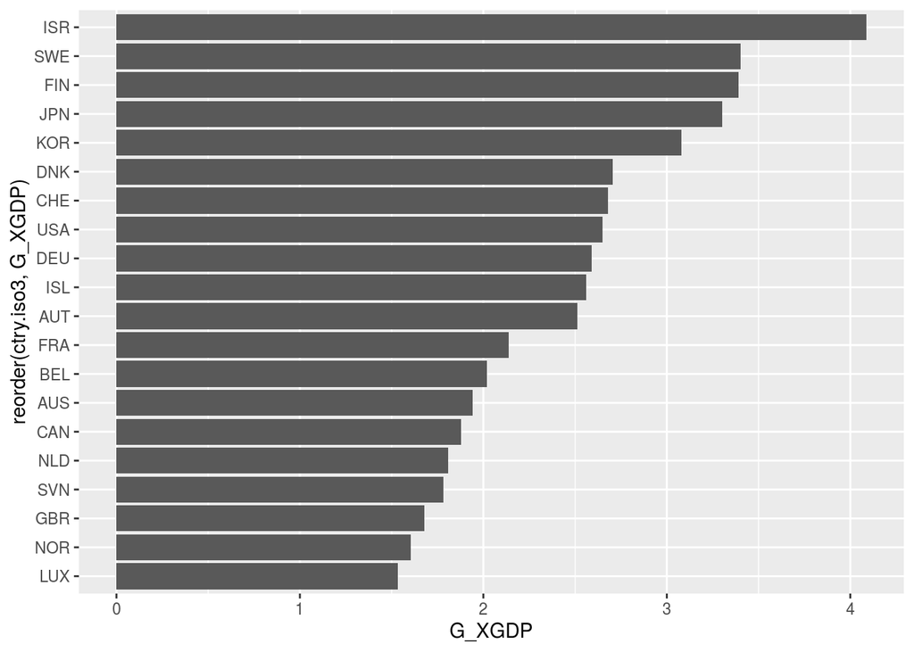

```r
data_wide_agg %>%
  arrange(desc(G_XGDP)) %>%
  slice(1:20) %>%
  ggplot(aes(x = reorder(ctry.iso3, G_XGDP), y = G_XGDP)) +
  geom_bar(stat="identity") +
  coord_flip()
```

### 0.5.3 Patent Output

- Finally, also look at an output, such as triadic (USTPO+EPO+JPO joint applications) patents.

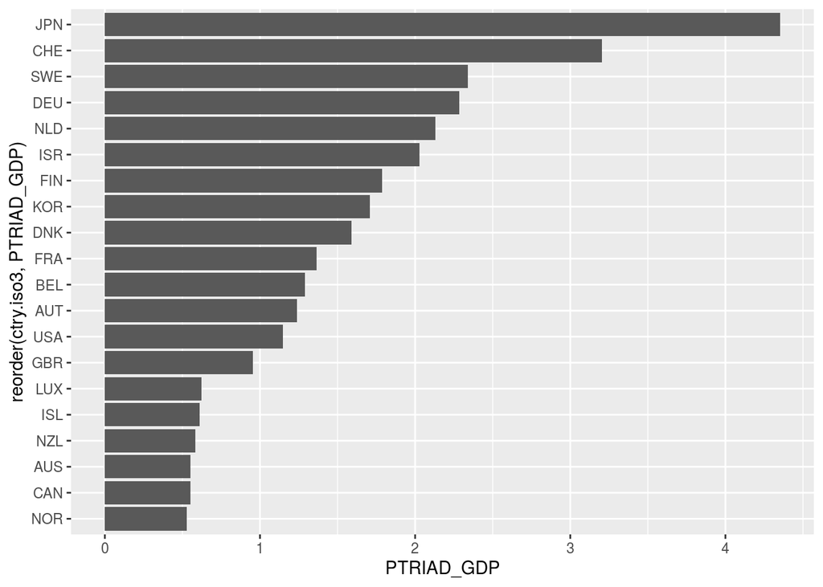

```r
data_wide_agg %>%
  arrange(desc(PTRIAD_GDP)) %>%
  slice(1:20) %>%
  ggplot(aes(x = reorder(ctry.iso3, PTRIAD_GDP), y = PTRIAD_GDP)) +
  geom_bar(stat="identity") +
  coord_flip()
```

## 0.6 Comparisons between countries, and relationships between indicators

- Next, it is often helpful to see how two indicators tend to develop together, and how countries scopre on them jointly. It for example makes sense to investigate to which extend some inputs (eg. GERD) translate into outputs (eg. patent applications).
- I also plot a regression line with `geom_smooth(method = "lm")`
- The interactive hover effect I get with using the `ggplotly()`

### 0.6.1 Patents & GDP

```r
p_pat <- data_wide_agg %>%
  ggplot(aes(x =  G_XGDP, y = PTRIAD_GDP, size = GDP_PPPK, colour = GDP_GRO)) +
  geom_point(alpha = 0.9) +
  geom_text(aes(label = ctry.iso3), hjust = 0, vjust = 0, size = 4, color = "black") +
  geom_smooth(method = "lm", se = FALSE, linetype = "dashed", alpha = 0.75) +
  theme(legend.position = "bottom") +
  labs(x = "GERD as % of GDP",
       y = "Triadic Patents per mil. GDP")
```

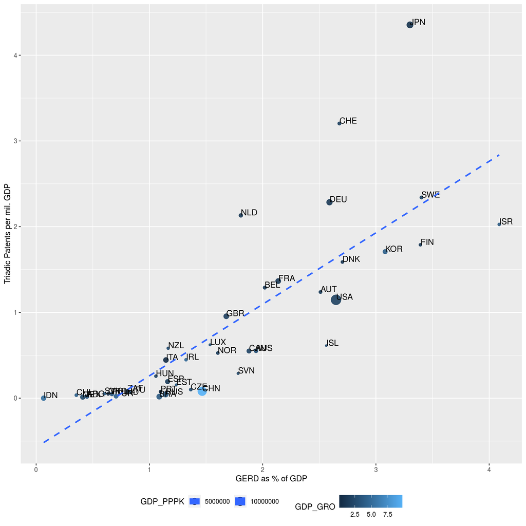

```r
p_pat # %>% plotly::ggplotly()
```

There indeed seems to be a relationship. Yet, some countries appear to translate their inputs more efficiently into output.

Lets take a look if goverment expenditure also translates into growth

```r
p_g_p <- data_wide_agg %>%
  ggplot(aes(x =  G_XGDP, y = GDP_GRO, size = GDP_PPPK)) +
  geom_point(alpha = 0.9) +
  geom_text(aes(label = ctry.iso3), hjust = 0, vjust = 0, size = 4, color = "black") +
  geom_smooth(method = "lm", se = FALSE, linetype = "dashed", alpha = 0.75) +
  theme(legend.position = "bottom") +
  labs(x = "GERD as % of GDP",
       y = "GDP growth %")
```

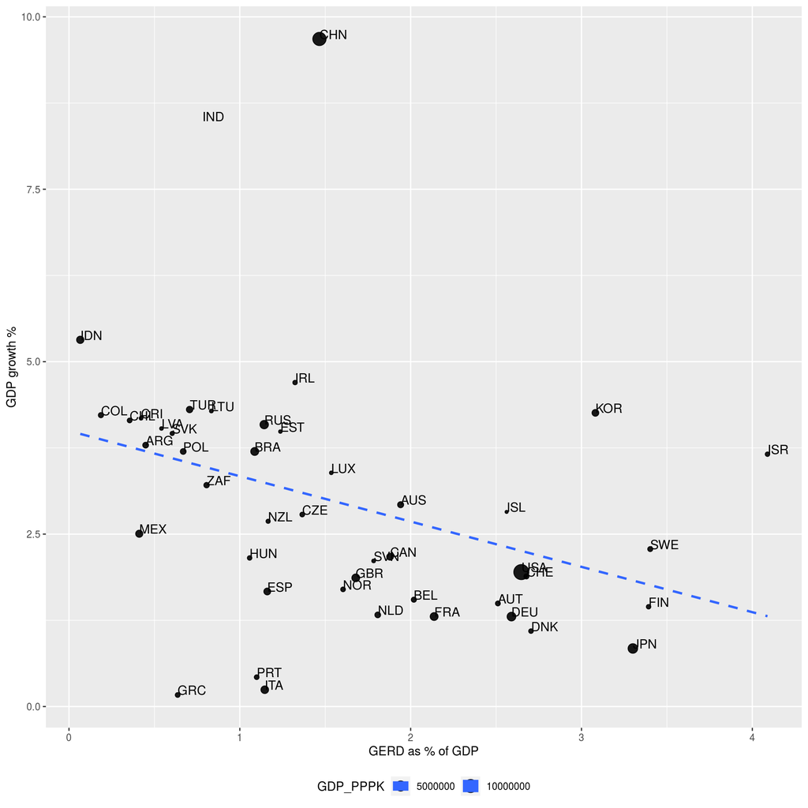

```r
p_g_p # %>% plotly::ggplotly()
```

## 0.7 Trends and dynamics

- Up to now, we only looked at average stats over the whole 2000-2016 period.
- Now, lets have a look what changed over time.
- To look at changes in all countries will probably be somewhat confusing visual, so we here only look at a selection.

```r
ctry <- c("DNK", "DEU", "CHN", "JPN", "KOR", "GBR", "USA")
```

### 0.7.1 GERD over time

We again start with GERD.

```r
p_t_gerd <- data_wide %>%
  filter(year <= 2014 & ctry.iso3 %in% ctry) %>%
  ggplot(aes(x = year, y = G_XGDP, color = ctry.iso3)) +
  geom_line(size = 1)
```

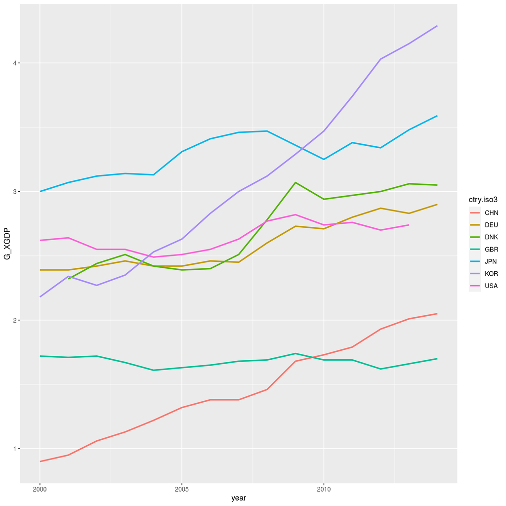

```r
p_t_gerd # %>% plotly::ggplotly()
```

### 0.7.2 Set of Indicators jointly

- We can also look at a set of indicators jointly.
- Here, the data in long format becomes handy, since we can just do a `facet_wrap()`, which will generate an own plot for every indicator.
- Since they all have different scales, we also set `scales = "free"`

```r
p_fac <- data %>%
  filter(year <= 2014 & ctry.iso3 %in% ctry) %>%
  ggplot(aes(x = year, y = value, color = ctry.iso3)) +
  geom_line(size = 1) +
  facet_wrap(~ indicator, scales = "free") +
  theme(legend.position = "bottom")
```

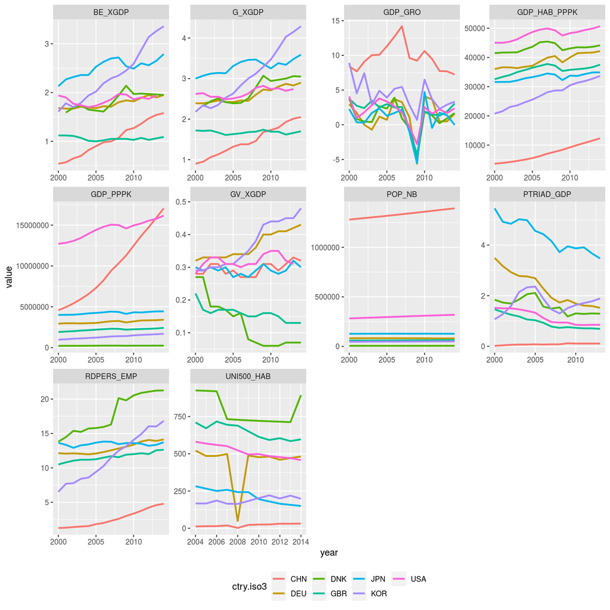

```r
p_fac # %>% plotly::ggplotly()
```

## 0.8 Catching up and development

- Finally, lets have a look at the development of countries along that indicators.
- This can be done similar to [Fagerberg & Srholec (2008). National innovation systems, capabilities and economic development. Research policy, 37(9), 1417-1435](https://www.sciencedirect.com/science/article/abs/pii/S0048733308001431) by comparing the initial level and the changes of indicators over time in a matrix.
- We will first create a new dataset, where we summarize all indicators for every 5 year period. That will make the results a bit more robust to tempral outliers and missing values for certain years.

```r
data_wide_p <- data_wide %>%
  select(-ctry.name, -year) %>%
  filter( !(ctry.iso3 %in% c("OECD", "EU28"))) %>%
  group_by(ctry.iso3, period) %>%
  summarize_all(mean, na.rm = TRUE) %>%
  ungroup() %>%
  arrange(ctry.iso3, period)
```

### 0.8.1 Calculating Deltas

- Now, we generate the procentual differenence between the indicators in the first and last period, which we call `xxx_delta`.
- We only keep the obervations for period 1 then.

```r
data_wide_p %<>%
  group_by(ctry.iso3) %>%
  mutate(GDP_HAB_PPPK_delta =  (lead(GDP_HAB_PPPK, n = 2) - GDP_HAB_PPPK) / GDP_HAB_PPPK,
         G_XGDP_delta =  (lead(G_XGDP, n = 2) - G_XGDP) / G_XGDP,
         PTRIAD_GDP_delta = (lead(PTRIAD_GDP, n = 2) - PTRIAD_GDP) / PTRIAD_GDP) %>%
  ungroup() %>%
  filter(period == 1 & !(ctry.iso3 %in% c("PRT", "ITA", "GRC", "LUX")))
```

```r
data_wide_p %>% head()
```

| ctry.iso3 | period | BE_XGDP | G_XGDP | GDP_GRO | GDP_HAB_PPPK | GDP_PPPK | GV_XGDP | PTRIAD_GDP | RDPERS_EMP | POP_NB | UNI500_HAB | GDP_HAB_PPPK_delta | G_XGDP_delta | PTRIAD_GDP_delta |
| --- | --- | --- | --- | --- | --- | --- | --- | --- | --- | --- | --- | --- | --- | --- |
| ARG | 1 | 0.09833333 | 0.3566667 | 8.890000 | 14836.36 | 570974.8 | 0.1383333 | 0.02166667 | 2.858333 | NaN | NaN | 0.30700182 | 0.6612150 | -0.5384615 |
| AUS | 1 | 0.88166667 | 1.6200000 | 3.196667 | 38297.25 | 757130.8 | 0.3033333 | 0.80333333 | 11.346667 | 19605.000 | 698.07 | 0.14606814 | 0.3055556 | -0.6141079 |
| AUT | 1 | 1.50333333 | 2.1150000 | 1.998333 | 38686.74 | 313734.4 | 0.1166667 | 1.38000000 | 11.260000 | 8108.157 | 670.75 | 0.10902882 | 0.3938534 | -0.1425121 |
| BEL | 1 | 1.32333333 | 1.8750000 | 2.118333 | 37423.49 | 387534.2 | 0.1333333 | 1.53666667 | 12.760000 | 10357.745 | 669.87 | 0.08242621 | 0.2560000 | -0.3405640 |
| BRA | 1 | NaN | 0.9933333 | 2.878000 | 11611.63 | 2084172.5 | NaN | 0.02000000 | 1.900000 | 177437.000 | 21.95 | 0.27125667 | 0.2181208 | -0.5000000 |
| CAN | 1 | 1.14666667 | 1.9700000 | 3.008333 | 38176.80 | 1202382.8 | 0.1983333 | 0.66833333 | 12.218333 | 31480.883 | 716.68 | 0.09032794 | -0.1256345 | -0.4114713 |

And now we can plot the initial value of the indicator against its chang over time, which gives us a good idea of the countries development.

```r
p_dev <- data_wide_p %>%
  ggplot(aes(x =  GDP_HAB_PPPK, y = GDP_HAB_PPPK_delta, size = GDP_PPPK, color = G_XGDP_delta)) +
  geom_point(alpha = 0.9) +
  geom_text(aes(label = ctry.iso3), hjust = 0, vjust = 0, size = 4, color = "black")
```

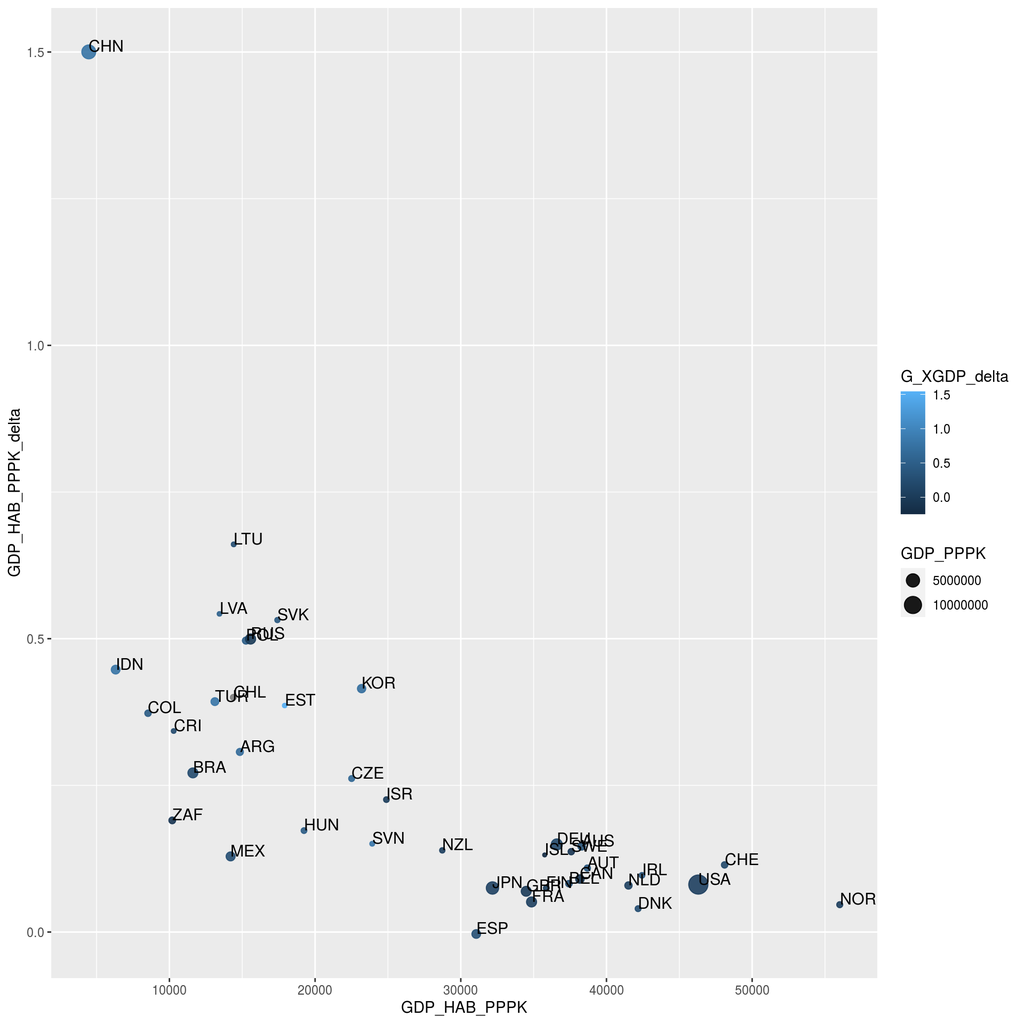

```r
p_dev #  # %>% plotly::ggplotly()
```

Well, not that bad, but for our final exercise, we can do nicer. We will take this plot and make it a bit clearer, with a couple of simple measures.

- Since the data has quite some outliers, we will plot it all on a log-scale (`scale_x_log10(), scale_y_log10()`)
- We add proper titel, andaxis descriptions to make the the plot understandable.
- We add horizontal and vertical lines at the median of the indicators.
- We name the resulting quadrants a la Fagerberg & Srholec (2008).

```r
p_dev_pretty <- p_dev +
  geom_hline(yintercept = median(data_wide_p$GDP_HAB_PPPK_delta, na.rm = TRUE), linetype = "dashed") +
  geom_vline(xintercept = median(data_wide_p$GDP_HAB_PPPK, na.rm = TRUE), linetype = "dashed") +
  annotate("text", x = 10000, y = 0.05, colour = "red", size = 5, label = "Falling behind") +
  annotate("text", x = 10000, y = 1.0, colour = "red", size = 5, label = "Catching up") +
  annotate("text", x = 45000, y = 0.05, colour = "red", size = 5, label = "Loosing momentum") +
  annotate("text", x = 45000, y = 1.0, colour = "red", size = 5, label = "Moving Ahead") +
  scale_x_log10() +
  scale_y_log10() +
  theme(legend.position = "bottom") +
  labs(title = "Economic development since 2000",
       subtitle = "Inivial GDP vs. GDP growth",
       x = "log. Initial GDP \n av. 2000-2005 compared with 2010-2015, constant USD ppp",
       y = "log. GDP Growth \n av. 2000-2005 compared with 2010-2015, constant USD ppp")
```

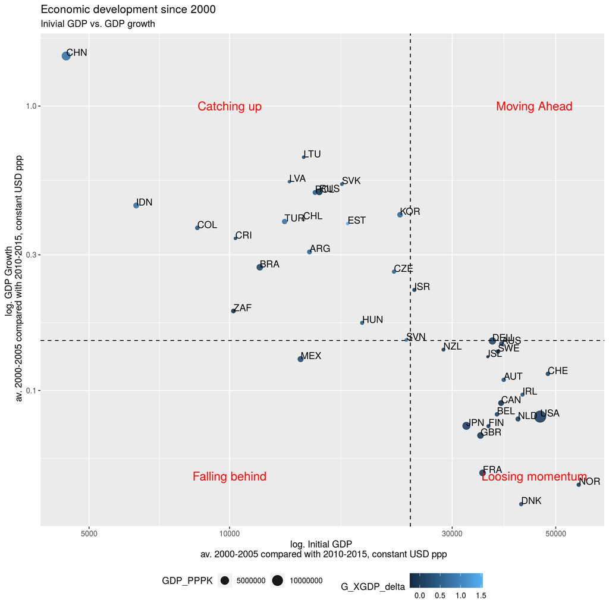

```r
p_dev_pretty  # %>% plotly::ggplotly()
```

## 0.9 Geo-spatial visualization

```r
data_map <- data_wide %>%
  select(-ctry.iso3, -year) %>%
  group_by(ctry.name) %>%
  summarize_all(mean, na.rm = TRUE) %>%
  ungroup()
```

- First, we need a map. `ggplot`already provides with `map_data` a dataset with all the country coordinates. It can also produce country level maps in a similar way, but more on that later.
- We just amke two changes. We delete the Antarctica, since it takes a lot of space and is not that interesting in terms of economic activity. We also recode the country names of the USA and UK to full names. For whatever reasons they are abbreviated in `map_data`.

```r
map_world <- map_data("world") %>%
  filter(region != "Antarctica") %>%
  mutate(region = region %>% recode(
    USA = "United States",
    UK = "United Kingdom"))
```

```r
map_world %>% head()
```

|  | long | lat | group | order | region | subregion |
| --- | --- | --- | --- | --- | --- | --- |
| 1 | -69.89912 | 12.45200 | 1 | 1 | Aruba | NA |
| 2 | -69.89571 | 12.42300 | 1 | 2 | Aruba | NA |
| 3 | -69.94219 | 12.43853 | 1 | 3 | Aruba | NA |
| 4 | -70.00415 | 12.50049 | 1 | 4 | Aruba | NA |
| 5 | -70.06612 | 12.54697 | 1 | 5 | Aruba | NA |
| 6 | -70.05088 | 12.59707 | 1 | 6 | Aruba | NA |

- We now just join it with our OECD STI indicators.

```r
map_world %<>%
  left_join(data_map, by = c("region" = "ctry.name" )  )
```

And we can directly plot it. We therefore use the `geom_polygon()` layer. We also use a nicer color palett from the `viridis` package.

```r
p_map <-map_world %>%
  ggplot(aes(x = long, y = lat, group = group)) +
  geom_polygon(aes(fill = UNI500_HAB)) +
  viridis::scale_fill_viridis(option = 'plasma') +
  theme_bw()
```

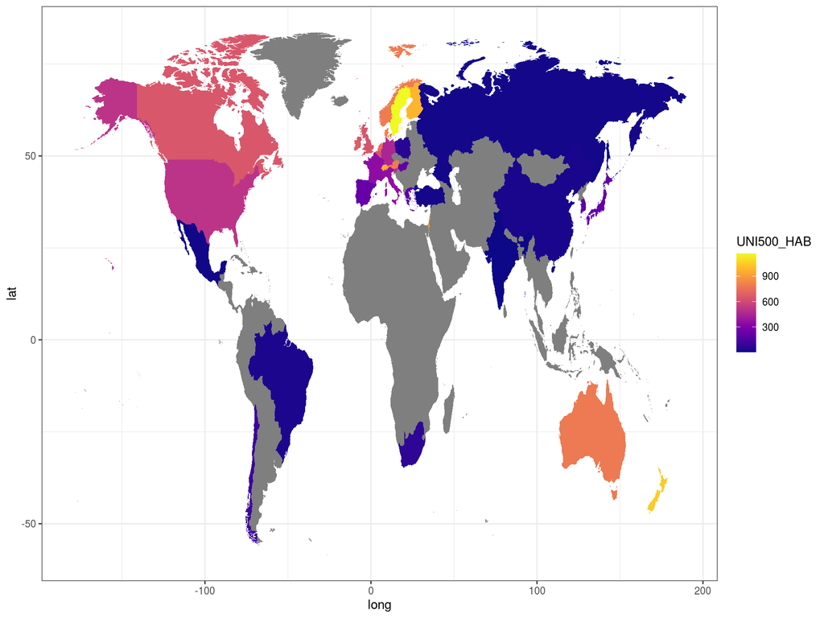

```r
p_map #  # %>% plotly::ggplotly()
```

Pretty, right?